# CVDRM PSED Report

### Tirzepatide

**Age**

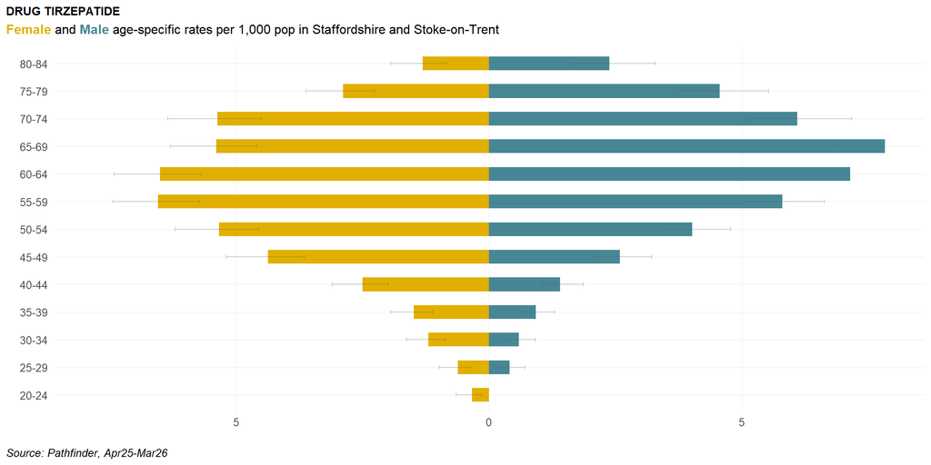

**Sex or Stated Gender**

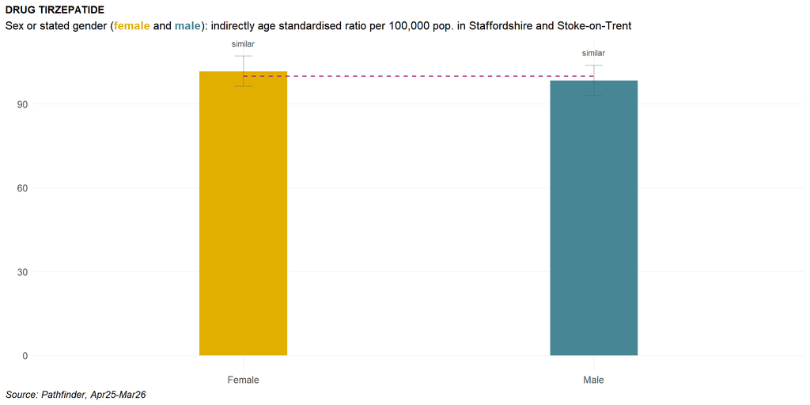

**Ethnicity**

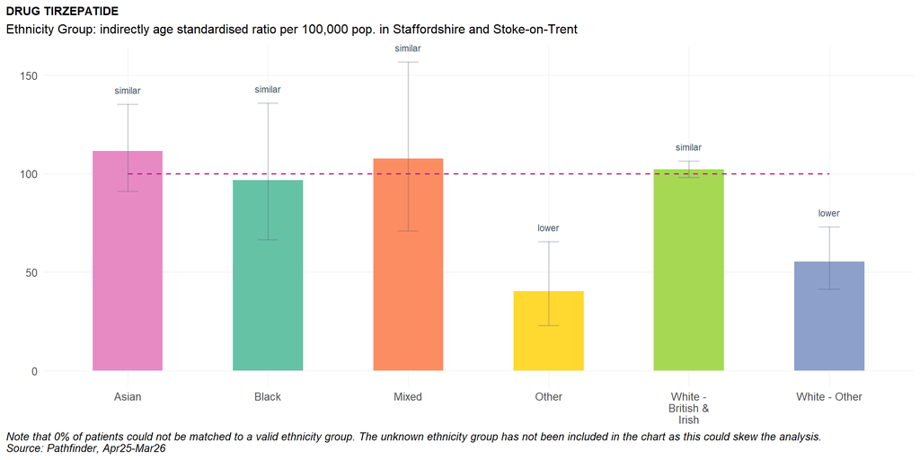

**Deprivation**

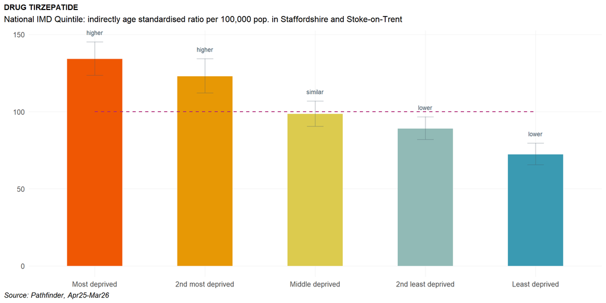

**Urban-Rural**

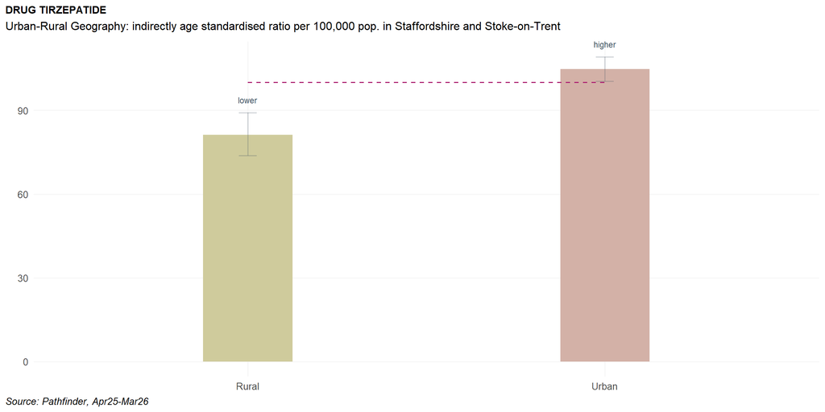

- Rates are highest in the 65-69 age group, whilst the median age is approx. 61 years.
- There was no significant variation by sex.
- Patients of Other ethnicity or patients of White - Other ethnicity had a significantly lower rate.
- Patients from the two most deprived groups had a significantly higher rate whilst patients from the two least deprived groups had a significantly lower rate.
- Patients from urban areas had a significantly higher rate, whilst patients from rural areas had a significantly lower rate.

### SGLT2 inhibitors

**Age**

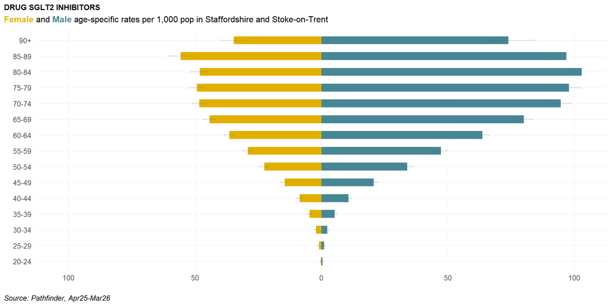

**Sex or Stated Gender**

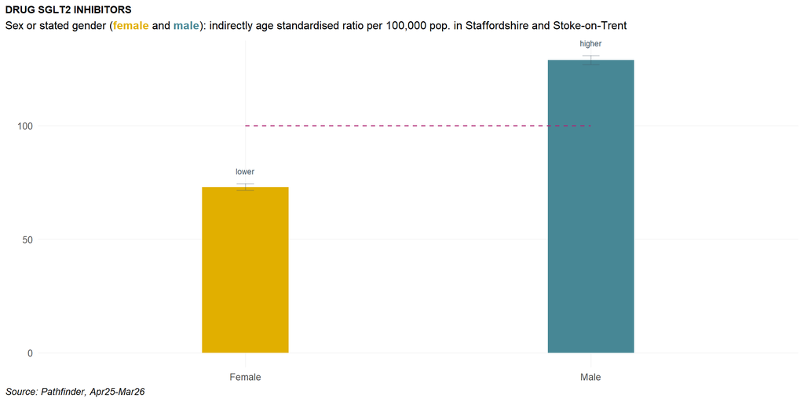

**Ethnicity**

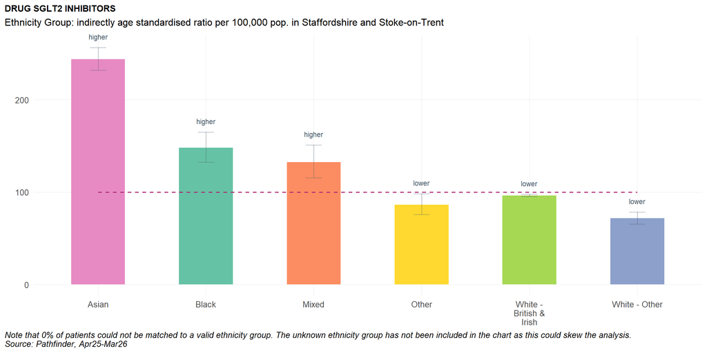

**Deprivation**

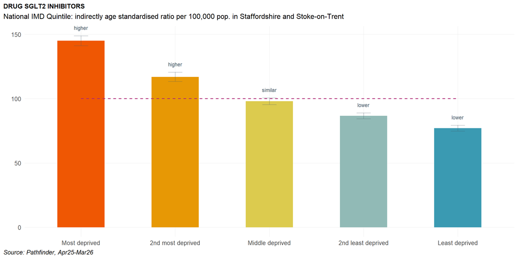

**Urban-Rural**

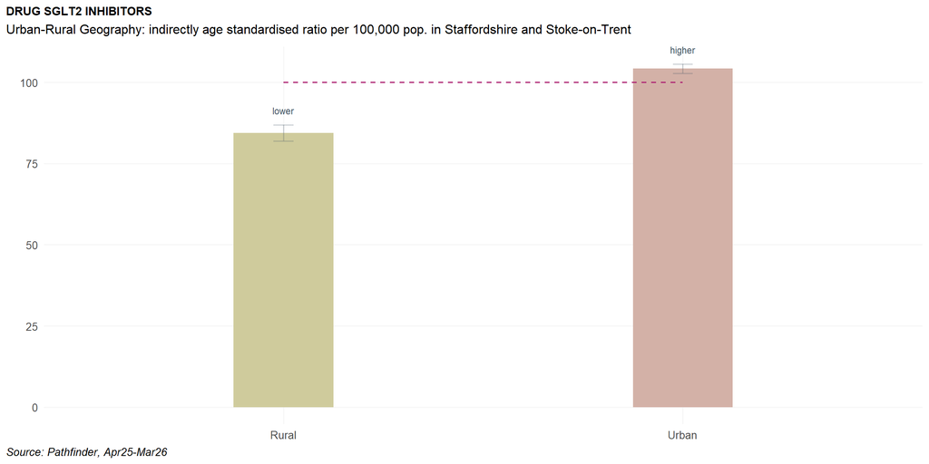

- Rates are highest in the 80-84 age group, whilst the median age is approx. 68 years.
- Males had a significantly higher rate, whilst females had a significantly lower rate.
- Patients of Asian ethnicity, patients of Black ethnicity or patients of Mixed ethnicity had a significantly higher rate, whilst patients of Other ethnicity, patients of White - British & Irish ethnicity or patients of White - Other ethnicity had a significantly lower rate.
- Patients from the two most deprived groups had a significantly higher rate whilst patients from the two least deprived groups had a significantly lower rate.
- Patients from urban areas had a significantly higher rate, whilst patients from rural areas had a significantly lower rate.

## Patient management

### Hypertension: Treated to appropriate threshold (all ages)

**Age**

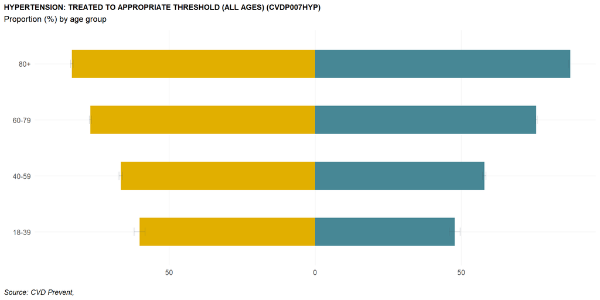

**Sex or Stated Gender**

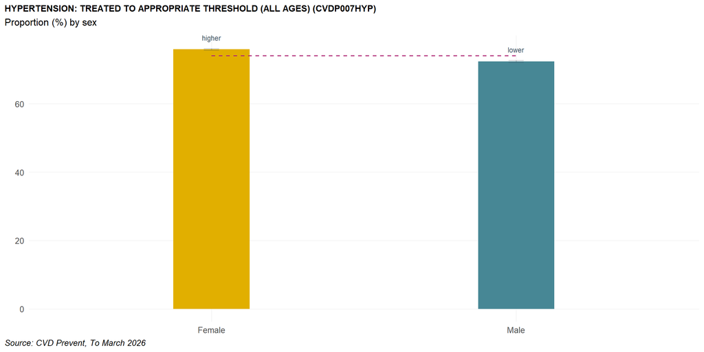

**Ethnicity**

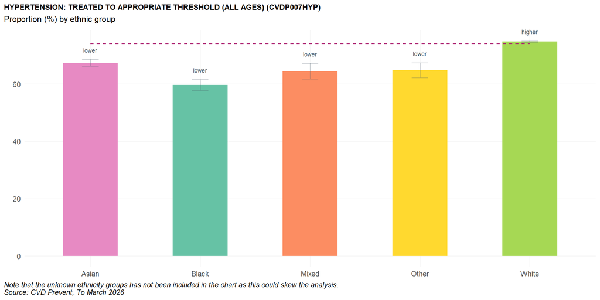

**Deprivation**

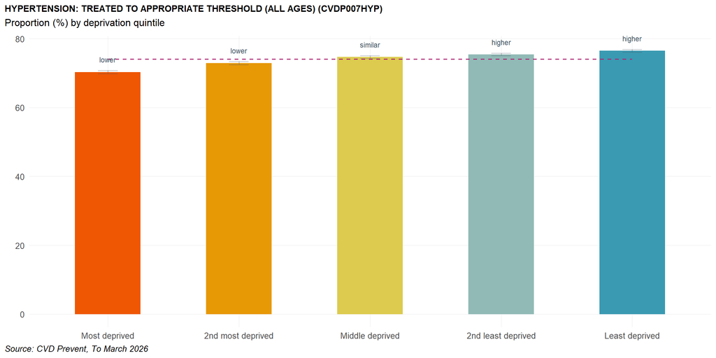

**Mental Health**

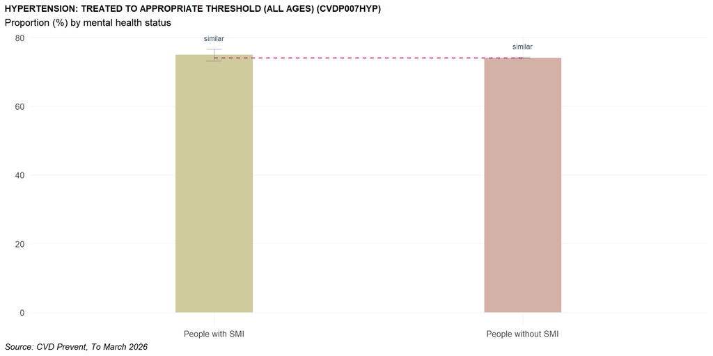

**Learning Disability**

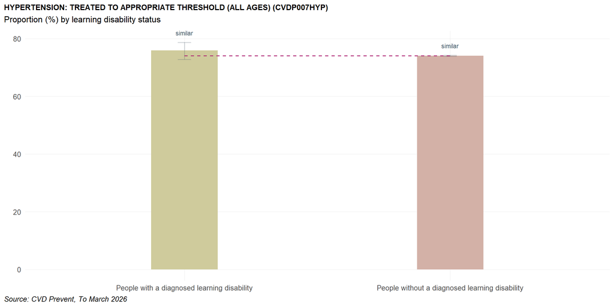

- Rates are highest in the 80+ year old age group.
- Females had a significantly higher rate, whilst males had a significantly lower rate.
- Patients of White ethnicity had a significantly higher rate, whilst patients of Asian ethnicity, patients of Black ethnicity, patients of Mixed ethnicity or patients of Other ethnicity had a significantly lower rate.
- Patients from the 2nd least deprived and least deprived group(s) had a significantly higher rate whilst patients from the most deprived and 2nd most deprived group(s) had a significantly lower rate.
- There was no significant variation by Mental Health.
- There was no significant variation by Learning Disability.